# Chapter 2

Ken Wu

11/28/2020

## Exercises

### Exercise 1

```r
# Objects
a <- 1:10
b <- a
c <- b
d <- 1:10
# Access object identifier
cat(obj_addr(a))
0x7f958cd003d8
cat(obj_addr(b))
0x7f958cd003d8
cat(obj_addr(c))
0x7f958cd003d8
cat(obj_addr(d))
0x7f958b02cf18
# Check if same
cat(identical(obj_addr(a), obj_addr(b)))
TRUE
cat(identical(obj_addr(a), obj_addr(c)))
TRUE
cat(identical(obj_addr(a), obj_addr(d)))
FALSE
```

**My solution:** In the first line, an object, which is a numeric sequence from 1 to 10, is created and it is bound to the name “a” using the <- operator. In the second line, R creates another binding from the name “b” to the already existing numeric sequence. Note that R does not create another copy of the sequence (memory efficient) but only adds another name reference to the same value. In the third line, R creates another binding to the existing numeric sequence from the name “c”. In the last line, R creates another copy of the numeric sequence and R is binding the numeric sequence to a name “d”.

**Textbook:** “a”,“b”, and “c” point to the **same object (with the same address in memory).** This object has the value 1:10. “d” points to a different object with the same value, but with different address in the memory.

### Exercise 2

```r
# Create a list containing the functions
mean_functions <- list(
  mean,
  base::mean,
  get("mean"),
  evalq(mean),
  match.fun("mean")
)
# Check for unique address
cat(unique(obj_addrs(mean_functions)))
0x7f958cb9f860
```

The following code all point to the same underlying function object with the same address in memory.

###Exercise 3

```r
read.csv(check.names = FALSE)
```

**Textbook:** Column names are often data, and the underlying make.names() transformation argument in the function read.csv() is non-invertible, so the default behavior corrupts data. To avoid this, set the argument check.names = FALSE in the function read.csv().

### Exercise 4

A **syntactically** valid name consists of letters, numbers and the dot or underline characters and starts with a letter or the dot. If it starts with dot, it must not be followed by a number. Names such as “.2way” are not valid, and neither are the **reserved** words. The rules that make.names() uses to convert non-syntactic names into syntactic ones are:

- Names that do not start with a letter or a dot will be prepended with an “X”. The same holds for names that begin with a dot followed by a number.

```r
cat(make.names("3")) # prepending "X"
X3
cat(make.names(".3")) # prepending "X"
X.3
```

- All invalid characters are translated to “.”

```r
cat(make.names("#")) # prepending "X" + "." replacement
X.
cat(make.names("  ")) # prepending "X" + ".." replacement
X..
cat(make.names("non-valid")) # "." replacement for "-"
non.valid
```

- Names that match R keywords are suffixed/appended by a dot

```r
cat(make.names("NULL")) # "." suffix
NULL.
```

- A missing value is translated to “NA”
- The definition of a letter depends on the current locale, but only American Standard Code for Information Interchange digits are considered to be digits

### Exercise 5

A syntactic name must start with either a letter or the dot and must not be followed by a number. The name “.123e1” is not a syntactic name. In fact, .123e1 makes it a double = 1.23.

```r
cat(make.names(".123e1")) # prepending with "X"
X.123e1
```

## Copy-on-modify

```r
# Bind x and y to the same underlying value
x <- c(1, 2, 3)
y <- x
# Modify the 3rd element of y
y[[3]] <- 4
# View x, which is unchanged
cat(x)
1 2 3
# Identifiers
cat(obj_addr(x))
0x7f958c160018
cat(obj_addr(y))
0x7f958c1546e8
```

## tracemem()

```r
# Bind value x
x <- c(1, 2, 3)
# Trace x
cat(tracemem(x))
<0x7f958de69688>
# Bind the same value to y
y <- x
# Modify y
y[[3]] <- 4L
tracemem[0x7f958de69688 -> 0x7f958d251278]: eval eval withVisible withCallingHandlers handle timing_fn evaluate_call <Anonymous> evaluate in_dir eng_r block_exec call_block process_group.block process_group withCallingHandlers process_file <Anonymous> <Anonymous>
# Modify y again
y[[3]] <- 5L
# Untrace
untracemem(y)
```

**What’s happening:** When modifying y again, it won’t get copied since the new object now only has a single name “y” bound to it; R applies modify-in-place optimization instead of copy-on-modify.

## Function calls

```r
# Function
f <- function(a) {
  a[[3]] <- 5L
}
# Bind value to x and trace
x <- c(1, 2, 3)
cat(tracemem(x))
<0x7f9590c6d928>
# Bind the object created by the function to z
z <- f(x)
tracemem[0x7f9590c6d928 -> 0x7f9590d31b28]: f eval eval withVisible withCallingHandlers handle timing_fn evaluate_call <Anonymous> evaluate in_dir eng_r block_exec call_block process_group.block process_group withCallingHandlers process_file <Anonymous> <Anonymous>
# Untrace
untracemem(x)
```

**What’s happening:** Since f() modifies the object referenced by x, the object gets copied and this new object’s third element is modified. “z”, then, binds this new object.

## Lists

```r
# Create a list
l1 <- list(1, 2, 3)
# Bind the same list object to l2
l2 <- l1
# Proof
obj_addr(l1)
[1] "0x7f9590de1d18"
obj_addr(l2)
[1] "0x7f9590de1d18"
# Modify list
l2[[3]] <- 4
# Values shared across lists
ref(l1, l2)
█ [1:0x7f9590de1d18] <list>
├─[2:0x7f958f906cf8] <dbl>
├─[3:0x7f958f906cc0] <dbl>
└─[4:0x7f958f906c88] <dbl>

█ [5:0x7f9590d24658] <list>
├─[2:0x7f958f906cf8]
├─[3:0x7f958f906cc0]
└─[6:0x7f958f906b38] <dbl>
```

A list stores the values of each element and the references/bindings to those values. When an element in a list is modified, a **shallow** modified copy is created. That is, the list object and its bindings are copied, but the value objects pointed to by the bindings are not copied. The opposite is a deep copy, which, prior to R 3.1.0, copies were always deep copies. As can be seen, the values(1 and 2) bound by the first two elements of both lists are not copied; both lists share these values. For the third element of l2, a new object is created for the value(4) it binds. Now, there are a total of four values/objects with four unique “addresses.”

### Why should we pre-allocate output containers when iterating?

Examine the example below. Using `c()`, `append()`, `cbind()`, `rbind()`, `paste()`, or modifying an object using `x[[i]] <- y` can create copies in a for loop.

```r
# Instantiate an empty list
y <- list()
# For loop
for (i in 1:10) {
  y[[i]] <- i
  cat(lobstr::obj_addr(y), "\n")
}
0x7f958f399bd8
0x7f958c196c48
0x7f958c32a338
0x7f958c32a298
0x7f9590bc3958
0x7f9590bc3878
0x7f9590bc3728
0x7f9590bc35d8
0x7f958c2efa28
0x7f958c2ef8c8
```

As can be seen, in each iteration, R creates a new copy and rebind y to the new modified object. This pattern holds for other types of operations such as `y <- append(y, i)`. This is because R must first allocate space for the new object and then copy the old object to its new home. This will be quite expensive when the number of iterations is high. However, if we pre-allocate an output container, we can avoid the copying behavior:

```r
# Pre-allocate empty container
y <- vector(mode = "list", length = 10)
# For loop
for (i in seq_along(y)) {
  y[[i]] <- i
  cat(lobstr::obj_addr(y), "\n")
}
0x7f9588eea0c8
0x7f9588eea0c8
0x7f9588eea0c8
0x7f9588eea0c8
0x7f9588eea0c8
0x7f9588eea0c8
0x7f9588eea0c8
0x7f9588eea0c8
0x7f9588eea0c8
0x7f9588eea0c8
```

## Data Frames

Data frames are lists of vectors.

```r
# Create a 3x2 data frame
d1 <- data.frame(x = c(1, 5, 6), y = c(2, 4, 3))
# Identifiers
cat(obj_addr(d1))
0x7f958de13f88
cat(obj_addr(d1$x))
0x7f958d250eb8
cat(obj_addr(d1$y))
0x7f958d250e18
# Bind same data frame object to d2
d2 <- d1
# Proof
cat(obj_addr(d2))
0x7f958de13f88
cat(obj_addr(d2$x))
0x7f958d250eb8
cat(obj_addr(d2$y))
0x7f958d250e18
# Modify second column of data frame 2
d2[, 2] <- d2[, 2] * 2
# Shared objects
ref(d1, d2)
█ [1:0x7f958de13f88] <df[,2]>
├─x = [2:0x7f958d250eb8] <dbl>
└─y = [3:0x7f958d250e18] <dbl>

█ [4:0x7f958eebc608] <df[,2]>
├─x = [2:0x7f958d250eb8]
└─y = [5:0x7f9590b578b8] <dbl>
```

Notice that only the second column needs to be modified; the others will still point to their original references.

```r
# Bind original data frame object to d3
d3 <- d1
# Proof
cat(obj_addr(d3))
0x7f958de13f88
cat(obj_addr(d3$x))
0x7f958d250eb8
cat(obj_addr(d3$y))
0x7f958d250e18
# Modify first row of data frame 3
d3[1, ] <- d3[1, ] * 3
# Shared objects
ref(d1, d3)
█ [1:0x7f958de13f88] <df[,2]>
├─x = [2:0x7f958d250eb8] <dbl>
└─y = [3:0x7f958d250e18] <dbl>

█ [4:0x7f958a55d588] <df[,2]>
├─x = [5:0x7f9590de1728] <dbl>
└─y = [6:0x7f9590de16d8] <dbl>
```

Notice, when a row is modified, both columns of d1 are copied and modified; d3 has two new objects bound to x and y (or, equivalently, referenced/pointed to by x and y).

## Charater vectors

R uses a **global string pool** where each element of a character vector is a pointer to a unique string int he pool:

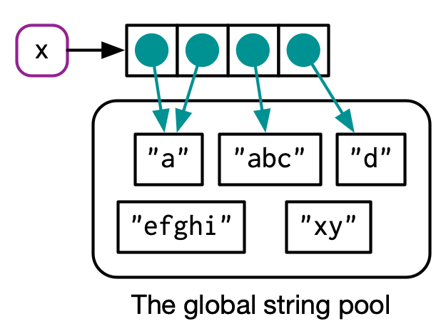

Figure 1: The Global String Pool

```r
# Import image
knitr::include_graphics("Global string pool.png")
```

```r
# Create a character vector and bind it to x
x <- c("a", "a", "abc", "d")
# Identifiers
cat(obj_addr(x))
0x7f9588f1e6a8
cat(ref(x, character = TRUE))
█ [1:0x7f9588f1e6a8] <chr> ├─[2:0x7f95872d1e28] <string: "a"> ├─[2:0x7f95872d1e28] ├─[3:0x7f958e9e3bf8] <string: "abc"> └─[4:0x7f9588976958] <string: "d">
```

## Exercises

### Exercise 1

```r
# Identifier
cat(obj_addr(1:10)) # the object exists, but has no name
0x7f958fa93c48
```

**Textbook:** When 1:10 is called an object with an address in memory is created, but it is not bound to a name. Therefore, the object cannot be called or manipulated from R. As no copies will be made, it is not useful to track the object for copying.

### Exercise 2

```r
# Create a vector and bind it to x
x <- c(1L, 2L, 3L)
# Trace
cat(tracemem(x))
<0x7f958dbff4c8>
# Modify
x[[3]] <- 4
tracemem[0x7f958dbff4c8 -> 0x7f958d8a7f08]: eval eval withVisible withCallingHandlers handle timing_fn evaluate_call <Anonymous> evaluate in_dir eng_r block_exec call_block process_group.block process_group withCallingHandlers process_file <Anonymous> <Anonymous>
tracemem[0x7f958d8a7f08 -> 0x7f958c138938]: eval eval withVisible withCallingHandlers handle timing_fn evaluate_call <Anonymous> evaluate in_dir eng_r block_exec call_block process_group.block process_group withCallingHandlers process_file <Anonymous> <Anonymous>
```

```r
# Create a vector and bind it to x
x <- c(1L, 2L, 3L)
# Trace
cat(tracemem(x))
<0x7f958dd6ee48>
# Modify
x[[3]] <- 4L
tracemem[0x7f958dd6ee48 -> 0x7f958e8a1d48]: eval eval withVisible withCallingHandlers handle timing_fn evaluate_call <Anonymous> evaluate in_dir eng_r block_exec call_block process_group.block process_group withCallingHandlers process_file <Anonymous> <Anonymous>
```

### Exercise 3

```r
# Create objects
a <- 1:10
b <- list(a, a)
c <- list(b, a, 1:10)
# Trees of references
ref(a)
[1:0x7f958d3d86f0] <int>
ref(b)
█ [1:0x7f958f9de088] <list>
├─[2:0x7f958d3d86f0] <int>
└─[2:0x7f958d3d86f0]
ref(c)
█ [1:0x7f9590d404a8] <list>
├─█ [2:0x7f958f9de088] <list>
│ ├─[3:0x7f958d3d86f0] <int>
│ └─[3:0x7f958d3d86f0]
├─[3:0x7f958d3d86f0]
└─[4:0x7f958d4fd1b8] <int>
```

**My solution:** The first line creates a value (aka a numeric sequence) and binds it to the name “a” with address a. The second line creates a list object, which stores the numeric sequence and the references to them, and binds the list object to the name “b”, which has a new address b. The two elements in “b” references/point to the same value pointed to by “a”. The last line creates a list object and binds it to the name “c” with address c; elements in c has bindings to the same object as b and a and also a new object, which is the numeric sequence 1:10 that has a address d. There are a total of 4 objects, since there are 4 unique addresses.

**Textbook:** “a” contains a reference to an address with the value 1:10. “b” contains a list of two references to the same address as “a”. “c” contains a list of “b” (containing two references to a), “a” (containing the same reference again) and a reference pointing to a different address containing the same value (1:10).

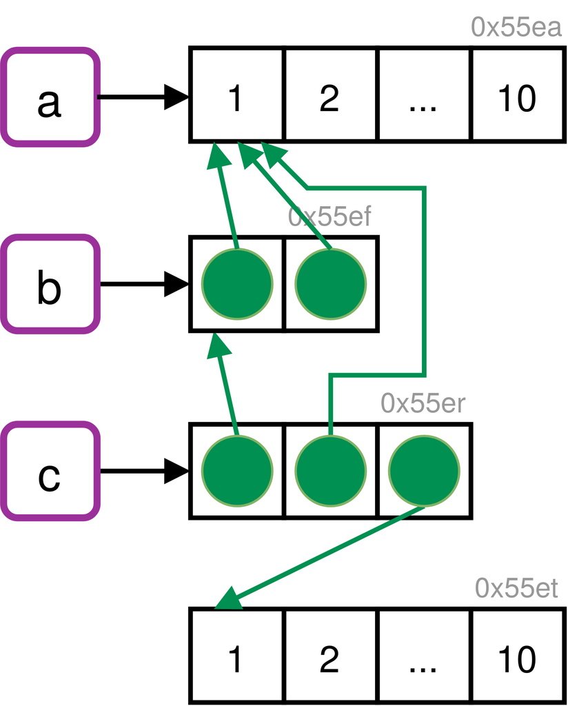

Figure 2: Tree

```r
# Import image
knitr::include_graphics("Reference Tree.png")
```

```r
ref(c)
█ [1:0x7f9590d404a8] <list>
├─█ [2:0x7f958f9de088] <list>
│ ├─[3:0x7f958d3d86f0] <int>
│ └─[3:0x7f958d3d86f0]
├─[3:0x7f958d3d86f0]
└─[4:0x7f958d4fd1b8] <int>
# c
# - b
# -- a
# -- a
# - a
# - 1:10
```

### Exercise 4

```r
# Create a list and bind it to x
x <- list(1:10)
# Reference Tree
ref(x)
█ [1:0x7f9590dfb3d0] <list>
└─[2:0x7f958f322fd0] <int>
```

The initial reference tree of x shows that the name x binds to a list object with an address. This object contains a reference to the integer vector 1:10, which has an address.

```r
# Trace
cat(tracemem(x))
<0x7f9590dfb3d0>
# Modify list as x is assigned to the second element of itself
x[[2]] <- x
tracemem[0x7f9590dfb3d0 -> 0x7f958c17c840]: eval eval withVisible withCallingHandlers handle timing_fn evaluate_call <Anonymous> evaluate in_dir eng_r block_exec call_block process_group.block process_group withCallingHandlers process_file <Anonymous> <Anonymous>
```

Here, a modified copy of the list is made; however, it is a shallow copy since the integer vector is not copied. The list object previously bound to x is now referenced in the newly created list object. It is no longer bound to a name. The integer vector is referenced twice:

```r
# Reference Tree
ref(x)
tracemem[0x7f9590dfb3d0 -> 0x7f958c2aa538]: FUN lapply FUN lapply ref eval eval withVisible withCallingHandlers handle timing_fn evaluate_call <Anonymous> evaluate in_dir eng_r block_exec call_block process_group.block process_group withCallingHandlers process_file <Anonymous> <Anonymous>
█ [1:0x7f958c19c7c8] <list>
├─[2:0x7f958f322fd0] <int>
└─█ [3:0x7f9590dfb3d0] <list>
  └─[2:0x7f958f322fd0]
```

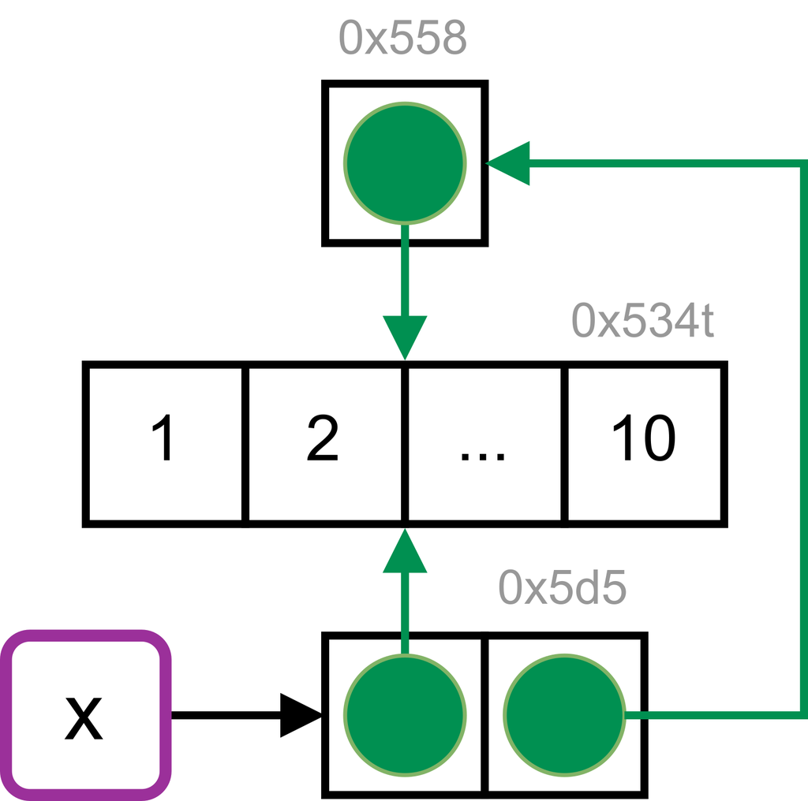

Figure 3: Tree

```r
# Import image
knitr::include_graphics("Reference Tree 2.png")
```

## Object Size

```r
# Create a vector value and bind it to x
x <- runif(1e6)
# Identifier
cat(obj_addr(x))
0x7f9591400000
# Size
obj_size(x)
8,000,048 B
# Create a list and bind it to y
y <- list(x, x, x)
# Identifier
cat(obj_addr(y))
0x7f9590b7c348
# Reference Tree
ref(y)
█ [1:0x7f9590b7c348] <list>
├─[2:0x7f9591400000] <dbl>
├─[2:0x7f9591400000]
└─[2:0x7f9591400000]
# Size
obj_size(y)
8,000,128 B
```

Since the elements of lists are references to values, the size of a list might be much smaller than expected. Furthermore, obj_size(x) + obj_size(y) will only equal obj_size(x,y) if there are no shared values. Notice “y” is only 80 bytes bigger than x, which is the size of an empty list with three elements:

```r
# Empty list
obj_size(list(NULL, NULL, NULL))
80 B
```

```r
# Character vector
banana <- "bananas bananas bananas"
# Size
obj_size(banana)
136 B
obj_size(rep(banana, 100))
928 B
```

**Alternative Representation:** Instead of storing every single number in the sequence, R just stores the first and last number, meaning every sequence, no matter how large, is the same size:

```r
obj_size(1:3)
680 B
obj_size(1:1e3)
680 B
obj_size(1:1e6)
680 B
obj_size(1:1e9)
680 B
```

## Exercises

### Exercise 1

```r
# Create an list object and bind it to y
# list(runif(1e4)) creates a list of 1 element, which references a double vector
# rep() creates a list where each element is the aforementioned list of 1 element
y <- rep(list(runif(1e4)), 100)
# Sizes
obj_size(y)
80,896 B
object.size(y)
8005648 bytes
```

### Exercise 2

```r
# Create a list of functions and bind it to "funs"
funs <- list(mean, sd, var)
# Individual Size
obj_size(mean)
1,184 B
obj_size(sd)
4,480 B
obj_size(var)
12,472 B
# Size of list containing these functions
obj_size(funs)
17,608 B
```

It is somewhat misleading, because all three functions are built-in to R as part of the base and stats packages and hence always available.

### Exercise 3

**My solutions:**

```r
a <- runif(1e6)
tracemem(a)
[1] "<0x7f9591ba2000>"
# Size
obj_size(a)
8,000,048 B
```

**Prediction for a:** 8,000,048 B. The textbook solution below explains further how this number comes about.

```r
b <- list(a, a)
# Size
obj_size(b)
8,000,112 B
obj_size(a, b)
8,000,112 B
# Reference tree
ref(a, b)
[1:0x7f9591ba2000] <dbl>

█ [2:0x7f958ebaf948] <list>
├─[1:0x7f9591ba2000]
└─[1:0x7f9591ba2000]
```

**Prediction for b:** 8,000,048 B (size of “a”) + 64 B (size of an empty list with two elements) = 8,000,112 B

**Prediction for (a,b):** This should be same as size of “b” since “a” and “b” have shared values so no addition memory is needed to store new objects

```r
b[[1]][[1]] <- 10
tracemem[0x7f9591ba2000 -> 0x7f9592344000]: eval eval withVisible withCallingHandlers handle timing_fn evaluate_call <Anonymous> evaluate in_dir eng_r block_exec call_block process_group.block process_group withCallingHandlers process_file <Anonymous> <Anonymous>
# Size
obj_size(b)
16,000,160 B
obj_size(a, b)
16,000,160 B
# Reference tree
ref(a, b)
[1:0x7f9591ba2000] <dbl>

█ [2:0x7f9590ade4c8] <list>
├─[3:0x7f9592344000] <dbl>
└─[1:0x7f9591ba2000]
```

**Prediction for b:** The new “b” should have double the size of “a” since a modified copy of “a” is made plus the size of an empty list with two elements 64 B; therefore, = 16,000,160 B

**Prediction for (a,b):** This should simply be the size of the new “b” (16,000,160 B). Since “a” references the numeric vector runif(1e6) already in existent, it does not need a new memory address. The first element of “b” is modified and the increase in object size is reflected in size of the new “b”. The second element of b, which is “a”, also references that existing vector; hence, there is no additional memory needed for the second element of the new “b”

```r
b[[2]][[1]] <- 10
tracemem[0x7f9591ba2000 -> 0x7f9592ae6000]: eval eval withVisible withCallingHandlers handle timing_fn evaluate_call <Anonymous> evaluate in_dir eng_r block_exec call_block process_group.block process_group withCallingHandlers process_file <Anonymous> <Anonymous>
# Size
obj_size(b)
16,000,160 B
obj_size(a, b)
24,000,208 B
# Reference tree
ref(b)
█ [1:0x7f958c028d08] <list>
├─[2:0x7f9592344000] <dbl>
└─[3:0x7f9592ae6000] <dbl>
# Reference tree
ref(a, b)
[1:0x7f9591ba2000] <dbl>

█ [2:0x7f958c028d08] <list>
├─[3:0x7f9592344000] <dbl>
└─[4:0x7f9592ae6000] <dbl>
```

**Prediction for b:** The object size of this new “b” should be 16,000,160 B since modifying the second element of the previous “b” triggers copy-on-modify. As can be seen in the reference tree for this new “b”, there are two memory addresses that the two elements in “b” reference/point to. Each of those vector values should have an object size of “a”, 8,000,048 B; two of them should have 8,000,048 B * 2 + 64 B = 16,000,160 B.

**textbook:** In R (on most platforms) a length-0 vector has 48 bytes of overhead:

```r
obj_size(list())
48 B
obj_size(double())
48 B
obj_size(character())
48 B
```

A single double takes up additional 8 bytes of memory:

```r
obj_size(double(1))
56 B
obj_size(double(2))
64 B
```

So, a 1 million double should take up 8,000,048 bytes. This is the object size of “a”.